# BIOS611 - Project I

# 2.Results from an Experiment on Plant Growth

```r
plantgrowth = as_tibble(PlantGrowth)
```

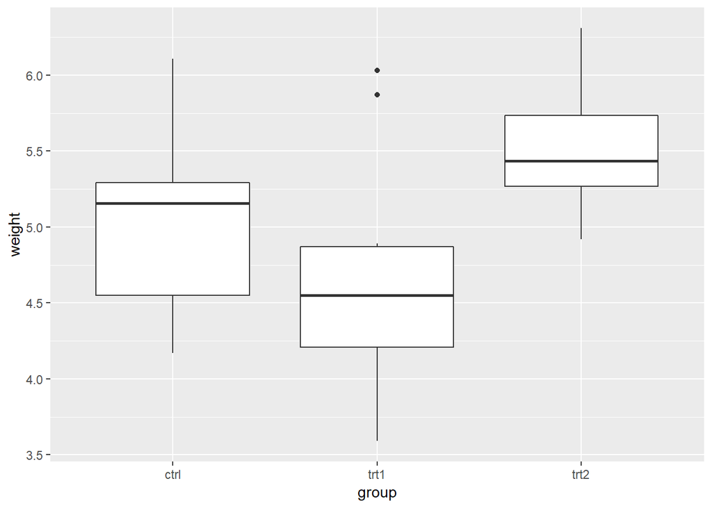

```r
ggplot(plantgrowth, aes(group, weight)) +
  geom_boxplot()
```

```r
plantgrowth %>% group_by(group) %>%
  summarize(mean_wt = mean(weight)) %>% knitr::kable()
```

| group | mean_wt |
| --- | --- |
| ctrl | 5.032 |
| trt1 | 4.661 |
| trt2 | 5.526 |

- The data was from an experiment to compare yields among a control and two treatment conditions, ans was used as an example in Dobson’s book “An Introduction to Statistical Modelling”. The weight of each dried plant is the measurement of interest. By graphing a boxplot and summarizing the data, it seems like treatment 2 yields heavier weight, and treatment 1 yields lighter weight than the weight of the control according to the summarized table above. As the next step, we can check if there is a significant difference in mean weight among these groups by performing ANOVA test and computing Tukey’s interval.

# 3.New York Air Quality Measurements

```r
nyair = as_tibble(na.omit(airquality))
```

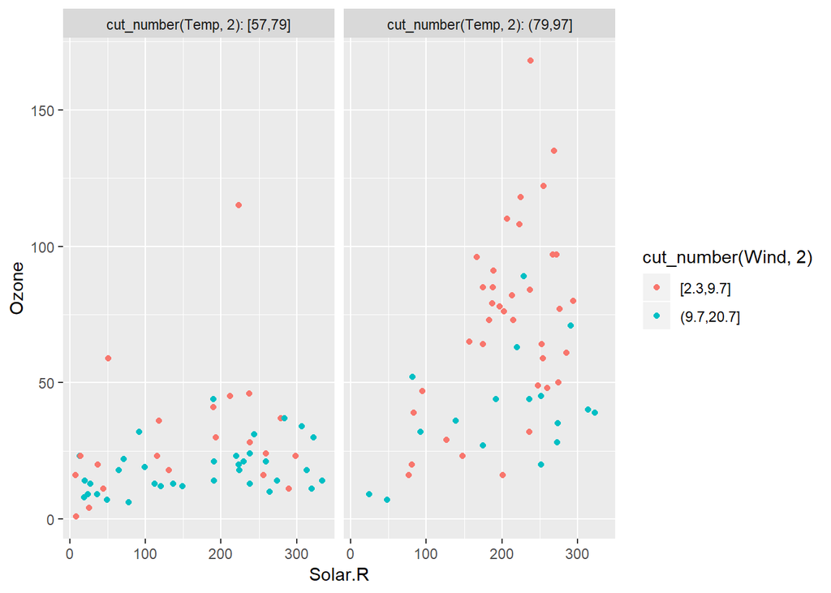

```r
#featurePlot(x = nyair[c("Temp", "Solar.R", "Wind")], y = nyair$Ozone)
ggplot(nyair, aes(Solar.R, Ozone)) +
  geom_point(aes(color = cut_number(Wind, 2))) +
  facet_wrap( ~ cut_number(Temp, 2), labeller = label_both)
```

```r
nyair %>% group_by(Month) %>%
  summarize(mean_temp = mean(Temp),
            mean_wind = mean(Wind),
            mean_soloarR = mean(Solar.R),
            mean_ozone = mean(Ozone)) %>%
  arrange(mean_ozone) %>% knitr::kable()
```

| Month | mean_temp | mean_wind | mean_soloarR | mean_ozone |
| --- | --- | --- | --- | --- |
| 5 | 66.45833 | 11.504167 | 182.0417 | 24.12500 |
| 6 | 78.22222 | 12.177778 | 184.2222 | 29.44444 |
| 9 | 76.89655 | 10.075862 | 168.2069 | 31.44828 |
| 7 | 83.88462 | 8.523077 | 216.4231 | 59.11538 |
| 8 | 83.69565 | 8.860870 | 173.0870 | 60.00000 |

- The data is the daily air quality measurements in New York from May to September in 1973 obtained from the New York State Department of Conservation(ozone data) and the National Weather service(meteorological data), and was used as an example in the book “Graphical Methods for Data Analysis” by John Chambers, William Cleveland, Paul Tukey and Beat Kleiner. `Ozone` is the measurement indicating the air quality. The higher the ozone, the worse the air quality. Based on the scatterplot above, the temperature seems to be the major factor that affects the relationship between ozone and solar radiation. As temperature is higher than 79 Fahrenheight, ozone increases as solar radiation increases. In contrast, as temperature is lower than 79 Fahrenheight, there is no relationship between ozone and solar radiation since ozone stays the same as solar radiation increases. In addition, according to the summarized table above, when the mean temperature is high during the month, that is when it is summer, the mean ozone tends to be higher, which is consistent with the conclusion we drew from the scatterplot. Therefore, temperature might be the most important factor to examine when predicting the air quality. To further validate this hypothesis, we can pull or collect more data and build a multivariate statistical model to see if the predictor temperature is the most significant.